# Assignment 3 - Classification

## Exercise 3.2

1. Using a dataset of your choice develop a classification model. Provide a very basic description of what you are doing and why.

The dataset used is the “Boston” dataset from the `MASS` package in R. The dataset has 506 observations with 14 variables and records housing values in the suburbs of Boston. I would like to predict the per capita crime rate based on several socio-economic indicators. One such indicator could be housing values. Other indicators that could be considered are housing size, presence of industry (non-retail business), pupil-teacher ratio, etc. A classification model (e.g. logistic regression) could be run to predict the probability of the presence of low or high crime rate, which could be informative for allocation of law enforcement/ resources.

The variables in the dataset are:

- `crim`: per capita crime rate by town
- `zn`: proportion of residential land zoned for lots over 25,000 sq. ft.
- `indus`: proportion of non-retail business acres per town
- `chas`: Charles River dummy variable (=1 if tract bounds river; 0 otherwise)
- `nox`: nitrogen oxides concentration (parts per 10 million)
- `rm`: average number of rooms per dwelling
- `age`: proportion of owner-occupied units built prior to 1940
- `dis`: weighted mean of distances to five Boston employment centres
- `rad`: index of accessibility to radial highways
- `tax`: full-value property-tax rate per $10,000
- `ptratio`: pupil-teacher ratio by town
- `black`: 1000(Bk - 0.63)^2 where Bk is the proportion of blacks by town
- `lstat`: lower status of the population (percent)
- `medv`: median value of owner-occupied homes in $1000s.

I re-classified some of the variables to prepare the dataset for analysis. I re-classified average room size by grouping them into 3 classes: “small” (if less than 4 rooms), “medium” (4 to 6 rooms), and “large” (more than or equal to 7 rooms). I also created a new binary variable for the response, `crim` (`crim01`).

```r
library("MASS")
data("Boston")
str(Boston)
```

```
'data.frame':   506 obs. of  14 variables:
 $ crim   : num  0.00632 0.02731 0.02729 0.03237 0.06905 ...
 $ zn     : num  18 0 0 0 0 0 12.5 12.5 12.5 12.5 ...
 $ indus  : num  2.31 7.07 7.07 2.18 2.18 2.18 7.87 7.87 7.87 7.87 ...
 $ chas   : int  0 0 0 0 0 0 0 0 0 0 ...
 $ nox    : num  0.538 0.469 0.469 0.458 0.458 0.458 0.524 0.524 0.524 0.524 ...
 $ rm     : num  6.58 6.42 7.18 7 7.15 ...
 $ age    : num  65.2 78.9 61.1 45.8 54.2 58.7 66.6 96.1 100 85.9 ...
 $ dis    : num  4.09 4.97 4.97 6.06 6.06 ...
 $ rad    : int  1 2 2 3 3 3 5 5 5 5 ...
 $ tax    : num  296 242 242 222 222 222 311 311 311 311 ...
 $ ptratio: num  15.3 17.8 17.8 18.7 18.7 18.7 15.2 15.2 15.2 15.2 ...
 $ black  : num  397 397 393 395 397 ...
 $ lstat  : num  4.98 9.14 4.03 2.94 5.33 ...
 $ medv   : num  24 21.6 34.7 33.4 36.2 28.7 22.9 27.1 16.5 18.9 ...
```

```r
summary(Boston)
```

```
      crim                zn             indus            chas
 Min.   : 0.00632   Min.   :  0.00   Min.   : 0.46   Min.   :0.00000
 1st Qu.: 0.08204   1st Qu.:  0.00   1st Qu.: 5.19   1st Qu.:0.00000
 Median : 0.25651   Median :  0.00   Median : 9.69   Median :0.00000
 Mean   : 3.61352   Mean   : 11.36   Mean   :11.14   Mean   :0.06917
 3rd Qu.: 3.67708   3rd Qu.: 12.50   3rd Qu.:18.10   3rd Qu.:0.00000
 Max.   :88.97620   Max.   :100.00   Max.   :27.74   Max.   :1.00000
      nox               rm             age              dis
 Min.   :0.3850   Min.   :3.561   Min.   :  2.90   Min.   : 1.130
 1st Qu.:0.4490   1st Qu.:5.886   1st Qu.: 45.02   1st Qu.: 2.100
 Median :0.5380   Median :6.208   Median : 77.50   Median : 3.207
 Mean   :0.5547   Mean   :6.285   Mean   : 68.57   Mean   : 3.795
 3rd Qu.:0.6240   3rd Qu.:6.623   3rd Qu.: 94.08   3rd Qu.: 5.188
 Max.   :0.8710   Max.   :8.780   Max.   :100.00   Max.   :12.127
      rad              tax           ptratio          black
 Min.   : 1.000   Min.   :187.0   Min.   :12.60   Min.   :  0.32
 1st Qu.: 4.000   1st Qu.:279.0   1st Qu.:17.40   1st Qu.:375.38
 Median : 5.000   Median :330.0   Median :19.05   Median :391.44
 Mean   : 9.549   Mean   :408.2   Mean   :18.46   Mean   :356.67
 3rd Qu.:24.000   3rd Qu.:666.0   3rd Qu.:20.20   3rd Qu.:396.23
 Max.   :24.000   Max.   :711.0   Max.   :22.00   Max.   :396.90
     lstat            medv
 Min.   : 1.73   Min.   : 5.00
 1st Qu.: 6.95   1st Qu.:17.02
 Median :11.36   Median :21.20
 Mean   :12.65   Mean   :22.53
 3rd Qu.:16.95   3rd Qu.:25.00
 Max.   :37.97   Max.   :50.00
```

```r
Boston$rmsize <- ifelse(Boston$rm < 4, 1,
                        ifelse(Boston$rm >= 4 & Boston$rm < 7, 2, 3))
table(Boston$rmsize)
```

```
  1   2   3
  2 440  64
```

```r
Boston$rmsize <- factor(Boston$rmsize, labels = c("small", "medium", "large"))
summary(Boston$rmsize)
```

```
 small medium  large
     2    440     64
```

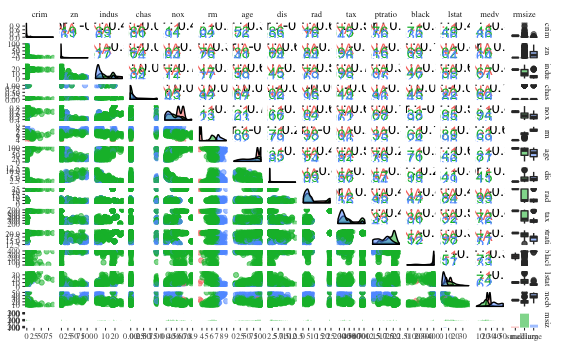

```r
Boston %>%
ggpairs(aes(color = rmsize, alpha = 0.2)) + theme_tufte(base_size = 8, base_family = "serif", ticks = TRUE)
```

```r
# Creating a binary variable for crime rate: crim01
# Assigning high crime rate (1) to crime rates equal and above the median
crim01 <- ifelse(Boston$crim >= (median(Boston$crim)), 1, 0)
Boston1 = data.frame(Boston, crim01)
str(Boston1)
```

```
'data.frame':   506 obs. of  16 variables:
 $ crim   : num  0.00632 0.02731 0.02729 0.03237 0.06905 ...
 $ zn     : num  18 0 0 0 0 0 12.5 12.5 12.5 12.5 ...
 $ indus  : num  2.31 7.07 7.07 2.18 2.18 2.18 7.87 7.87 7.87 7.87 ...
 $ chas   : int  0 0 0 0 0 0 0 0 0 0 ...
 $ nox    : num  0.538 0.469 0.469 0.458 0.458 0.458 0.524 0.524 0.524 0.524 ...
 $ rm     : num  6.58 6.42 7.18 7 7.15 ...
 $ age    : num  65.2 78.9 61.1 45.8 54.2 58.7 66.6 96.1 100 85.9 ...
 $ dis    : num  4.09 4.97 4.97 6.06 6.06 ...
 $ rad    : int  1 2 2 3 3 3 5 5 5 5 ...
 $ tax    : num  296 242 242 222 222 222 311 311 311 311 ...
 $ ptratio: num  15.3 17.8 17.8 18.7 18.7 18.7 15.2 15.2 15.2 15.2 ...
 $ black  : num  397 397 393 395 397 ...
 $ lstat  : num  4.98 9.14 4.03 2.94 5.33 ...
 $ medv   : num  24 21.6 34.7 33.4 36.2 28.7 22.9 27.1 16.5 18.9 ...
 $ rmsize : Factor w/ 3 levels "small","medium",..: 2 2 3 2 3 2 2 2 2 2 ...
 $ crim01 : num  0 0 0 0 0 0 0 0 0 0 ...
```

```r
summary(Boston1)
```

```
      crim                zn             indus            chas
 Min.   : 0.00632   Min.   :  0.00   Min.   : 0.46   Min.   :0.00000
 1st Qu.: 0.08204   1st Qu.:  0.00   1st Qu.: 5.19   1st Qu.:0.00000
 Median : 0.25651   Median :  0.00   Median : 9.69   Median :0.00000
 Mean   : 3.61352   Mean   : 11.36   Mean   :11.14   Mean   :0.06917
 3rd Qu.: 3.67708   3rd Qu.: 12.50   3rd Qu.:18.10   3rd Qu.:0.00000
 Max.   :88.97620   Max.   :100.00   Max.   :27.74   Max.   :1.00000
      nox               rm             age              dis
 Min.   :0.3850   Min.   :3.561   Min.   :  2.90   Min.   : 1.130
 1st Qu.:0.4490   1st Qu.:5.886   1st Qu.: 45.02   1st Qu.: 2.100
 Median :0.5380   Median :6.208   Median : 77.50   Median : 3.207
 Mean   :0.5547   Mean   :6.285   Mean   : 68.57   Mean   : 3.795
 3rd Qu.:0.6240   3rd Qu.:6.623   3rd Qu.: 94.08   3rd Qu.: 5.188
 Max.   :0.8710   Max.   :8.780   Max.   :100.00   Max.   :12.127
      rad              tax           ptratio          black
 Min.   : 1.000   Min.   :187.0   Min.   :12.60   Min.   :  0.32
 1st Qu.: 4.000   1st Qu.:279.0   1st Qu.:17.40   1st Qu.:375.38
 Median : 5.000   Median :330.0   Median :19.05   Median :391.44
 Mean   : 9.549   Mean   :408.2   Mean   :18.46   Mean   :356.67
 3rd Qu.:24.000   3rd Qu.:666.0   3rd Qu.:20.20   3rd Qu.:396.23
 Max.   :24.000   Max.   :711.0   Max.   :22.00   Max.   :396.90
     lstat            medv          rmsize        crim01
 Min.   : 1.73   Min.   : 5.00   small :  2   Min.   :0.0
 1st Qu.: 6.95   1st Qu.:17.02   medium:440   1st Qu.:0.0
 Median :11.36   Median :21.20   large : 64   Median :0.5
 Mean   :12.65   Mean   :22.53                Mean   :0.5
 3rd Qu.:16.95   3rd Qu.:25.00                3rd Qu.:1.0
 Max.   :37.97   Max.   :50.00                Max.   :1.0
```

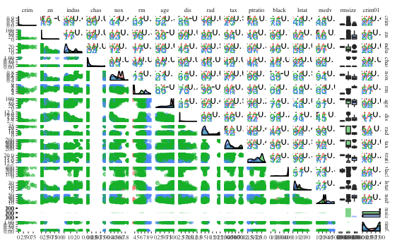

```r
Boston1 %>%
ggpairs(aes(color = rmsize, alpha = 0.2)) + theme_tufte(base_size = 8, base_family = "serif", ticks = TRUE)
```

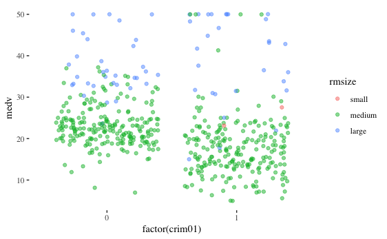

```r
plot1 <- ggplot(Boston1, aes(factor(crim01), medv, color = rmsize)) + geom_jitter(alpha = 0.5) + theme_tufte()
plot1
```

```r
# Areas with a higher median value of owner-occupied homes seem to have lower crime rates
```

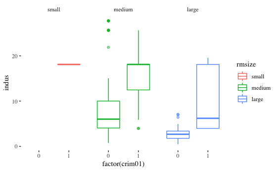

```r
plot2 <- ggplot(Boston1, aes(factor(crim01), indus, color = rmsize)) + geom_boxplot(alpha = 0.5) + theme_tufte()
plot2 + facet_grid(.~ rmsize)
```

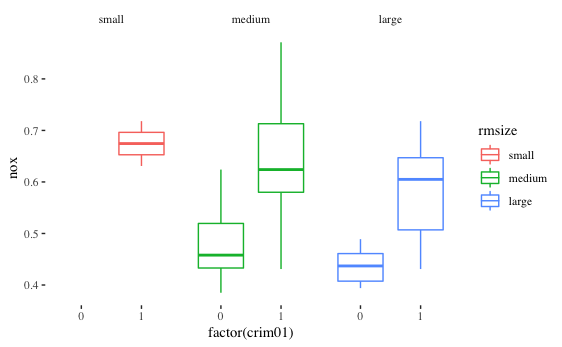

```r
# Higher proportion of non-retail business in an area is associated with higher crime rates
plot3 <- ggplot(Boston1, aes(factor(crim01), nox, color = rmsize)) + geom_boxplot(alpha = 0.5) + theme_tufte()
plot3 + facet_grid(.~ rmsize)
```

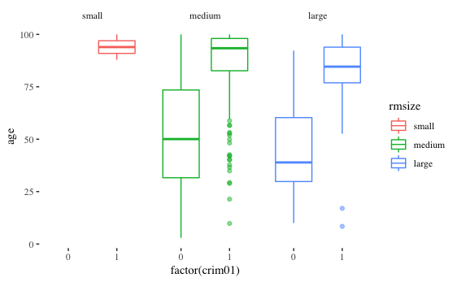

```r
# Higher NOx emissions in an area is also associated with higher crime rates
plot4 <- ggplot(Boston1, aes(factor(crim01), age, color = rmsize)) + geom_boxplot(alpha = 0.5) + theme_tufte()
plot4 + facet_grid(.~ rmsize)
```

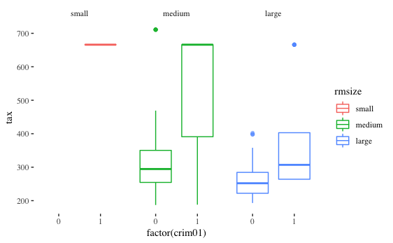

```r
# Newer houses seem to be associated with lower crime rates
plot5 <- ggplot(Boston1, aes(factor(crim01), tax, color = rmsize)) + geom_boxplot(alpha = 0.5) + theme_tufte()
plot5 + facet_grid(.~ rmsize)
```

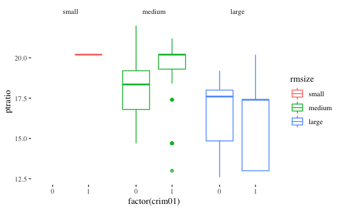

```r
# Higher levels of property tax rate seem to be associated with higher crime rates
plot6 <- ggplot(Boston1, aes(factor(crim01), ptratio, color = rmsize)) + geom_boxplot(alpha = 0.5) + theme_tufte()
plot6 + facet_grid(.~ rmsize)
```

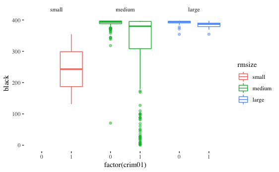

```r
# Lower pupil-teacher ratios may or may not be associated with crime rate levels
plot7 <- ggplot(Boston1, aes(factor(crim01), black, color = rmsize)) + geom_boxplot(alpha = 0.5) + theme_tufte()
plot7 + facet_grid(.~ rmsize)
```

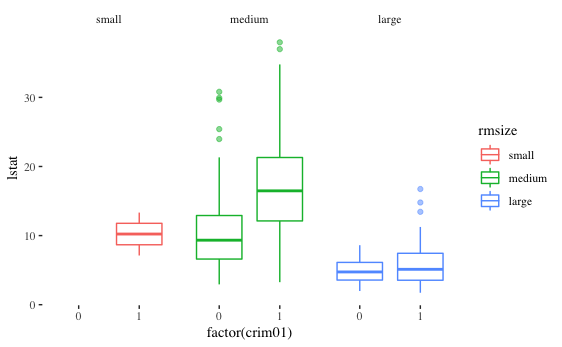

```r
# Proportion of black people in an area may or may not be associated with crime rate levels
plot8 <- ggplot(Boston1, aes(factor(crim01), lstat, color = rmsize)) + geom_boxplot(alpha = 0.5) + theme_tufte()
plot8 + facet_grid(.~ rmsize)
```

```r
# Areas with higher percentage of low-income population could be associated with higher crime rates
```

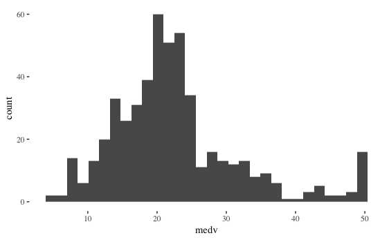

```r
# Checking frequency distribution of key predictor: medv
ggplot(Boston1, aes(medv)) + geom_histogram() + theme_tufte()
```

2. Implement the classifier (e.g. logistic regression) using implementations in user-written packages. Compare the results from the `glm` function in base R to the results from your alternative implementation (e.g. `lrm` function in `rms` package).

The regression model using the `glm` function in base R yielded a lower test error rate of 17.8% while the model using the `lrm` function in the `rms` package yielded a slightly higher test error rate of 19.8%. However, the model using the `lrm` function yielded lower standard errors indicating that it may be a slightly more efficient model.

```r
# Checking for class bias in response variable - Balanced
table(Boston1$crim01)
```

```
  0   1
253 253
```

```r
# Create test and training set
set.seed(1)
# For replicating results
# Shuffle rows
rows <- sample(nrow(Boston1))
# Randomly order data
Boston1 <- Boston1[rows, ]
# Identify row to split on
split <- round(nrow(Boston1)*0.60)
# Create train
bostontrain <- Boston1[1:split, ]
# Create test
bostontest <- Boston1[(split+1):nrow(Boston1), ]
# Check dimensions
dim(bostontrain)
```

```
[1] 304  16
```

```r
dim(bostontest)
```

```
[1] 202  16
```

```r
# Run logistic regression with `glm`
set.seed(1)
model3 <- glm(crim01 ~ medv + indus + nox + rmsize + age + lstat, data = bostontrain, family = binomial)
summary(model3)
```

```
Call:
glm(formula = crim01 ~ medv + indus + nox + rmsize + age + lstat,
    family = binomial, data = bostontrain)

Deviance Residuals:
     Min        1Q    Median        3Q       Max
-2.31628  -0.28589   0.00324   0.20869   2.94632

Coefficients:
              Estimate Std. Error z value Pr(>|z|)
(Intercept)   -8.48596  937.57164  -0.009    0.993
medv          -0.01673    0.04248  -0.394    0.694
indus         -0.06445    0.05037  -1.279    0.201
nox           37.56499    6.97370   5.387 7.18e-08 ***
rmsizemedium -11.45631  937.56385  -0.012    0.990
rmsizelarge  -10.24318  937.56413  -0.011    0.991
age            0.01538    0.01163   1.322    0.186
lstat         -0.03583    0.05563  -0.644    0.519
---
Signif. codes:  0 ‘***’ 0.001 ‘**’ 0.01 ‘*’ 0.05 ‘.’ 0.1 ‘ ’ 1

(Dispersion parameter for binomial family taken to be 1)

    Null deviance: 421.10  on 303  degrees of freedom
Residual deviance: 168.49  on 296  degrees of freedom
AIC: 184.49

Number of Fisher Scoring iterations: 14
```

```r
test.predict = predict(model3, bostontest, type = "response")
test.predict.class = ifelse(test.predict > 0.5, 1, 0)
table(bostontest$crim01, test.predict.class, dnn = c("Actual Crime Rate", "Predicted Crime Rate"))
```

```
                 Predicted Crime Rate
Actual Crime Rate  0  1
                0 88 18
                1 18 78
```

```r
mean(test.predict.class != bostontest$crim01)
```

```
[1] 0.1782178
```

```r
# Run logistic regression with `lrm`
library(rms)
model4 <- lrm(crim01 ~ medv + indus + nox + rmsize + age + lstat, data = bostontrain)
print(model4, digits=4, strata.coefs = FALSE, coefs = TRUE)
```

```
Logistic Regression Model

 lrm(formula = crim01 ~ medv + indus + nox + rmsize + age + lstat,
     data = bostontrain)

                      Model Likelihood     Discrimination    Rank Discrim.
                         Ratio Test           Indexes           Indexes
 Obs          304    LR chi2     252.61    R2       0.753    C       0.950
  0           147    d.f.             7    g        4.851    Dxy     0.900
  1           157    Pr(> chi2) <0.0001    gr     127.807    gamma   0.901
 max |deriv| 0.06                          gp       0.452    tau-a   0.451
                                           Brier    0.089

               Coef     S.E.    Wald Z Pr(>|Z|)
 Intercept     -15.8313 39.4896 -0.40  0.6885
 medv           -0.0167  0.0425 -0.39  0.6937
 indus          -0.0644  0.0504 -1.28  0.2008
 nox            37.5650  6.9737  5.39  <0.0001
 rmsize=medium  -4.1110 39.3043 -0.10  0.9167
 rmsize=large   -2.8979 39.3109 -0.07  0.9412
 age             0.0154  0.0116  1.32  0.1860
 lstat          -0.0358  0.0556 -0.64  0.5194
```

```r
lrmpredict = predict(model4, newdata = bostontest)
lrmpredict.class = ifelse(lrmpredict > 0.5, 1, 0)
table(bostontest$crim01, lrmpredict.class, dnn = c("Actual Crime Rate", "Predicted Crime Rate"))
```

```
                 Predicted Crime Rate
Actual Crime Rate  0  1
                0 91 15
                1 25 71
```

```r
mean(lrmpredict.class != bostontest$crim01)
```

```
[1] 0.1980198
```

3. Use the `caret` package to calculate the confusion matrix. Discuss the key results like sensitivity, specificity, kappa, etc. Calculate precision, recall, and F1 using any implementation on CRAN.

The model appears to have a relatively high accuracy rate of 0.82 (82%). The number of true positive cases (“Low crime rate”) was 88 (out of 106 cases), and number of true negative cases (“High crime rate”) was 78 (out of 96 cases). The prevalence (or prior probability) was 0.5248.

- *Sensitivity*: Sensitivity was 0.8302. This means that 83% of samples with the event were predicted accurately.
- *Specificity*: Specificity was 0.8125. This means that 81% of samples without the event were predicted accurately. The false-positive rate was then (1-0.8125) = 0.1875 or 18.8%.
- *Kappa*: Kappa statistic was 0.6427, which is relatively close to 1. This means that there is some concordance between predicted and observed classes.
- *Precision*: Precision was 0.8302 or 83%, which means that the model is quite precise.
- *Recall*: Recall was 0.8302 or 83%, which is also a relatively high rate of recall.
- *F1*: F1 was 0.8302 or 83%.

```r
# Convert crim01 and test.predict.class to factors:
bostontest$crimtest <- factor(bostontest$crim01)
p_class <- factor(test.predict.class, levels = levels(bostontest[["crimtest"]]))
```

```r
# Create confusion matrix
confusionMatrix(p_class, bostontest$crimtest, mode = "everything")
```

```
Confusion Matrix and Statistics

          Reference
Prediction  0  1
         0 88 18
         1 18 78

               Accuracy : 0.8218
                 95% CI : (0.7619, 0.8719)
    No Information Rate : 0.5248
    P-Value [Acc > NIR] : <2e-16

                  Kappa : 0.6427
 Mcnemar's Test P-Value : 1

            Sensitivity : 0.8302
            Specificity : 0.8125
         Pos Pred Value : 0.8302
         Neg Pred Value : 0.8125
              Precision : 0.8302
                 Recall : 0.8302
                     F1 : 0.8302
             Prevalence : 0.5248
         Detection Rate : 0.4356
   Detection Prevalence : 0.5248
      Balanced Accuracy : 0.8213

       'Positive' Class : 0
```

```r
# Precision : 0.8302
# Recall : 0.8302
# F1 : 0.8302
```

4. Produce the ROC curve and discuss the results.

```r
# Store actual and predicted results in a dataframe
p <- data.frame(crim01 = bostontest$crim01)
p$results <- predict(model3, bostontest, type = "response")
#Plot ROC curve
library(pROC)
roc <- roc(p$crim01, p$results, levels = levels(as.factor(p$crim01)))
roc
```

```
Call:
roc.default(response = p$crim01, predictor = p$results, levels = levels(as.factor(p$crim01)))

Data: p$results in 106 controls (p$crim01 0) < 96 cases (p$crim01 1).
Area under the curve: 0.9213
```

```r
# Area under the curve: 0.9213
```

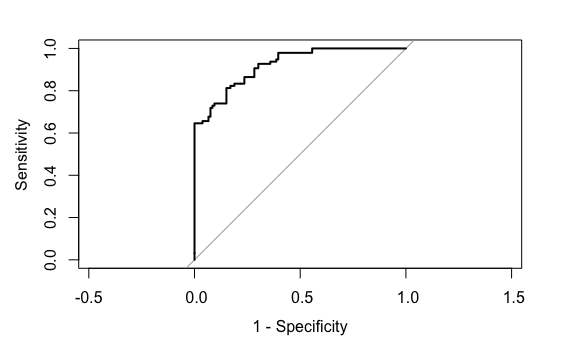

```r
# Plot ROC curve
plot(roc, legacy.axes = TRUE)
```

5. Assess class imbalance and implement any of the strategies to mitigate it.

If there is severe class imbalance, we should expect the ROC curve and the lift curve to be very similar. To assess if there is class imbalance, I plotted a lift curve and found that it was very dissimilar to the ROC curve, indicating that classes are already quite balanced. However, the lift plot also indicated that the model may actually not be informative.

One way to mitigate the presence of class imbalance is to alter the cut-off/ threshold, which could affect the predictive power of the model. Since the threshold was initially set at p > 0.5, I used different threshold levels to assess the effect on performance metrics including the test error rate, sensitivity and specificity.

A lower threshold of p > 0.3 improved the sensitivity of the model but decreased specificity. The test error rate was also higher at 20%. While a slightly higher threshold using Youden’s J index lowered the sensitivity of the model but achieved very high specificity. The test error rate was then lower at 15.8%. This means that with a lower threshold, the model predicts events more accurately. A higher threshold on the other hand allows the model to predict non-events more accurately.

```r
# Assess class imbalance
# Plot lift curve
p$crim01 <- as.factor(p$crim01)
labs <- c(results = "Logistic Regression")
lift <- lift(x = crim01 ~ results, data = p)
lift
```

```
Call:
lift.formula(x = crim01 ~ results, data = p)

Models: results
Event: 0 (52.5%)
```

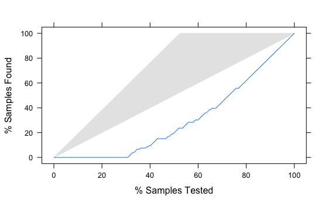

```r
#plot(roc, legacy.axes = TRUE)
xyplot(lift, auto.key = list(columns = 2, lines = TRUE, points= FALSE))
```

```r
# The lift curve is very different from the ROC curve, which could indicate that classes are quite balanced.
```

```r
# Deciding on a threshold - depends on your research question
# Using a different threshold
# Confusion matrix for initial threshold of p > 0.5
test.predict = predict(model3, bostontest, type = "response")
test.predict.class = ifelse(test.predict > 0.5, 1, 0)
tab1 <- table(bostontest$crim01, test.predict.class, dnn = c("Actual Crime Rate", "Predicted Crime Rate"))
# Confusion matrix for intial threshold of p > 0.9
new.predict = predict(model3, bostontest, type = "response")
new.predict.class = ifelse(new.predict > 0.3, 1, 0)
tab2 <- table(bostontest$crim01, new.predict.class, dnn = c("Actual Crime Rate", "Predicted Crime Rate"))
# Confusion matrix for threshold determined by pROC package
thresh <- coords(roc, x = "best", best.method = "youden")
new.predict.class1 = ifelse(new.predict > thresh, 1, 0)
```

```
longer object length is not a multiple of shorter object length
```

```r
tab3 <- table(bostontest$crim01, new.predict.class1, dnn = c("Actual Crime Rate", "Predicted Crime Rate"))
tab1.e <- mean(test.predict.class != bostontest$crim01)
tab2.e <- mean(new.predict.class != bostontest$crim01)
tab3.e <- mean(new.predict.class1 != bostontest$crim01)
sen1 <- sensitivity(tab1)
sen2 <- sensitivity(tab2)
sen3 <- sensitivity(tab3)
spec1 <- specificity(tab1)
spec2 <- specificity(tab2)
spec3 <- specificity(tab3)
error.rate <- tibble(Threshold = c("p > 0.5", "p > 0.3", "Youden's J index"), Error_Rate = c(tab1.e, tab2.e, tab3.e), Sensitivity = c(sen1, sen2, sen3), Specificity = c(spec1, spec2, spec3))
error.rate
```

| Threshold | Error_Rate | Sensitivity | Specificity |
| --- | --- | --- | --- |
| p > 0.5 | 0.1782178 | 0.8301887 | 0.8125000 |
| p > 0.3 | 0.2029703 | 0.8735632 | 0.7391304 |
| Youden's J index | 0.1584158 | 0.7846154 | 0.9444444 |

6. Implement a naive Bayes classifier. Briefly describe why it may be useful here and highlight it’s basic properties. Show the implementation and discuss the choice of parameters.

```r
# Create naive Bayes classifier
library(caret)
library(e1071)
library(klaR)
# using naiveBayes() function
x = Boston1[,-16]
x = x[,-1]
y = Boston1$crim01
yf = as.factor(y)
nbmodel = train(x, yf, method = 'nb', trControl = trainControl(method = 'cv', number = 10))
```

[output not shown]

```r
nbmodel
```

```
Naive Bayes

506 samples
 14 predictor
  2 classes: '0', '1'

No pre-processing
Resampling: Cross-Validated (10 fold)
Summary of sample sizes: 454, 456, 456, 455, 456, 455, ...
Resampling results across tuning parameters:

  usekernel  Accuracy   Kappa
  FALSE      0.8241418  0.6480698
   TRUE      0.8599864  0.7197323

Tuning parameter 'fL' was held constant at a value of 0
Tuning
 parameter 'adjust' was held constant at a value of 1
Accuracy was used to select the optimal model using the largest value.
The final values used for the model were fL = 0, usekernel = TRUE
 and adjust = 1.
```